# Dynamic population modelling demonstration with Julia

# Background

We will use an example from the book `A Practical Handbook for Population Viability Analysis` (Morris et al. 1999).

This example demonstrates possible code and techniques to perform population viability analysis using population Projection Matrix Models from the example in Box 4.1.

A Projection Matrix Model combines life-history data (transitions between different life stages) and abundance estimates to project possible future outcomes for a population. This example uses data on American Oystercatchers.

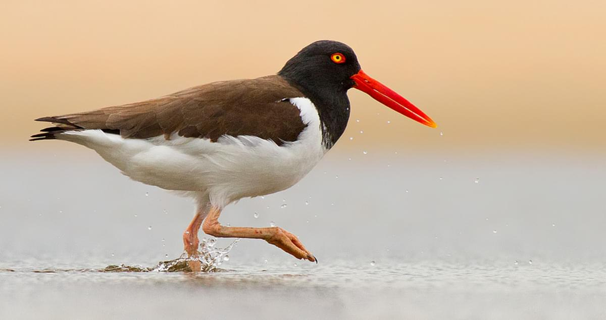

American Oystercatcher (CornellLab: All About Birds)

# Julia packages and environments

Julia uses environments to install and manage different packages that are used in a project. This is accessed by pressing `]` in the Julia terminal (return using `Ctrl + c`).

Required package names are recorded in the `Project.toml` file. Julia and package versions are recorded in the `Manifest.toml` file. These are machine-edited files that do not need to be edited manually.

Package management commands:

- `activate` : activate a new environment in the current folder. This creates `Project.toml` and `Manifest.toml` files to create an environment.
- `instantiate` : setup an environment from existing `*.toml` files. This is used if you clone a project from GitHub for example.
- `add` : Add a package (can include versions or GitHub repositories).
- `rm` : Remove a package from the environment.
- `status` : See current environment status (packages and julia version).
- `pin` : Set the version of a package(s) to be stable. This is useful for reproducibility and ensuring consistent package version use.

## Example

Use the REPL (terminal) to activate the package manager, and add `DataFrames` package. `]` -> `add DataFrames`

Then the package can be loaded in the session.

```julia
using DataFrames # `using` is similar to `library` in R.
using Statistics # provides statistical functions such as `median`, `quantile` etc.

# You can also use `import` instead of `using`
```

# Step 1: Stage-structured matrix

The first step of using a Projected Matrix Model is to create a transition matrix between components of the target population.

- Matrix rows and columns represent stages of the population of interest
- Values represent the rate of transition (annual or other temporal scale) between each combination of size classes
- Columns represent the stage transitioning FROM and rows represent the stage transitioning TO

To do this in Julia we create an object of type `Matrix{Float64}`.

```julia
# This is a square matrix where values represent transitions between population stages
# This matrix is in the format:
#                                   FROM
#                   Juveniles   Sub-adults  Adults
#       Juveniles       0           0           0.054
#   TO: Sub-adults      0.665       0           0
#       Adults          0           0.724       0.95

# There are multiple ways to create this matrix
# Simplest: Creating a matrix of Float64 values directly
ao_stage_matrix = [
    0      0      0.054;
    0.665   0      0;
    0      0.724  0.95
]

# Creating a matrix from DataFrame columns
ao_stages = DataFrame(
    to = ["juveniles", "sub_adults", "adults"], # Vector of strings
    juveniles = [0, 0.665, 0], # Vector of Float64
    sub_adults = [0, 0, 0.724],
    adults = [0.054, 0, 0.95]
)
# From selection of columns
ao_stage_matrix = Matrix(ao_stages[:, [:juveniles, :sub_adults, :adults]])

# From 'inverse' selection of columns
ao_stage_matrix = Matrix(ao_stages[:, Not(:to)])

ao_stage_matrix
```

```
3×3 Matrix{Float64}:
 0.0    0.0    0.054
 0.665  0.0    0.0
 0.0    0.724  0.95
```

# Step 2: Initial population conditions

Step 2 is to setup the initial population conditions in a population state vector. This holds current values for the abundance of each stage (i.e. N<sub>0</sub>).

```julia
# Initial population state in the format
#       J  S-A  A
N_0 = [40, 50, 60]
```

```
3-element Vector{Int64}:
 40
 50
 60
```

# Step 3: Matrix multiplication projection

The third step in projection matrix modelling is to project the population state using transition values. This is done through matrix * vector multiplication.

```julia
N_1 = ao_stage_matrix * N_0
```

```
3-element Vector{Float64}:
  3.2399999999999998
 26.6
 93.19999999999999
```

# Projection Matrix Modelling

Now we can turn the matrix multiplication into a model function that will project the population for a determined number of years.

Creating a function in julia uses the `function`, `return`, and `end` keywords.

```julia
function project_model(
    initial_conditions::Vector{<:Real},
    transition_parameter_matrix::Matrix{Float64},
    years::Int64
)::Matrix{Float64}
    # Create an empty array to hold the results for the model
    n_components = length(initial_conditions)
    proj_results = fill(NaN, n_components, years + 1)

    # Allocate the initial conditions to the initial year column
    proj_results[:, 1] = initial_conditions

    # Now loop through each year and combine the transition matrix with the previous year's population state
    for year in 1:years
        proj_results[:, year + 1] = transition_parameter_matrix * proj_results[:, year]
    end

    return proj_results
end
```

```
project_model (generic function with 1 method)
```

# Visualisation

Now we can project the population model for 100 years and visualise the projections.

```julia
projections_100t = project_model(N_0, ao_stage_matrix, 99)
```

```
3×100 Matrix{Float64}:
 40.0   3.24    5.0328    5.82111  …   0.656571   0.641618   0.627005
 50.0  26.6     2.1546    3.34681      0.446796   0.43662    0.426676
 60.0  93.2   107.798   103.968       11.8818    11.6112    11.3468
```

There are two main ecosystems for visualisation in julia: Plots.jl and Makie.jl

I will focus on Makie.jl for this session. `Makie.jl` is an ecosystem that contains a backend package (you do not need to install) and several front-end packages (that you will install) depending on your use case.

- CairoMakie.jl is great for fast, high resolution, publication quality plotting.
- GLMakie.jl is great for plotting interactively (zoom, navigate) while developing plots.
- Makie.jl also interacts with `AlgebraOfGraphics.jl` which is a plotting package similar to `ggplot2` in R.

## Plotting with base Makie.jl for fine-scale control

Using Makie.jl (with CairoMakie or GLMakie frontend) allows more fine-scale control, and more plot types (e.g. animations, 3D plots) but can take more time to develop compared to AlgebraOfGraphics.jl.

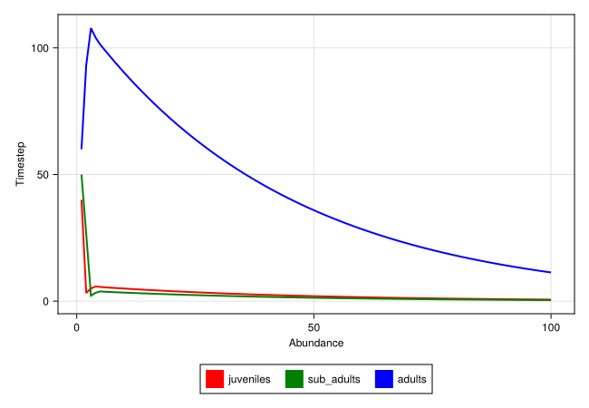

```julia
using CairoMakie

# Basic plotting:
fig = series(projections_100t)

# Finer control plotting:
fig = Figure(size = (650, 450), fontsize=12)
ax = Axis(fig[1, 1], xlabel="Abundance", ylabel="Timestep")

series!(ax, projections_100t, color=[:red, :green, :blue]) # Adding control of colours
legend_entries = [
    PolyElement(; color=:red),
    PolyElement(; color=:green),
    PolyElement(; color=:blue)
]
Legend(fig[2, 1], legend_entries, ["juveniles", "sub_adults", "adults"]; tell_width=false, tell_height=false, orientation=:horizontal)

fig
```

## Plotting algebraically with AlgebraOfGraphics.jl for speed

AlgebraOfGraphics.jl (AoG) allows you to get quickly get from DataFrame to a figure, similar to how ggplot2 works, but has fewer plot types available than base Makie.jl. AoG uses Makie.jl behind the scenes, so all plots can be custom modified using Makie.jl syntax to add legends, colour bars etc.

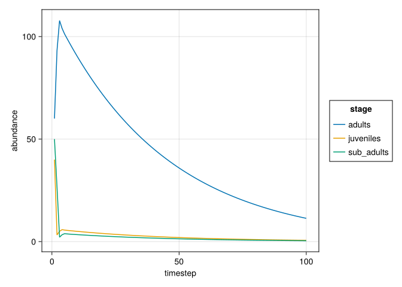

```julia
# using GLMakie # Would usually be required if not loaded already
using AlgebraOfGraphics

# To work with AlgebraOfGraphics.jl we need a DataFrame
# To do this we transpose the matrix and add column names
projection_df = DataFrame(Matrix(projections_100t'), ["juveniles", "sub_adults", "adults"])
projection_df.timestep = 1:nrow(projection_df)

# Convert this to a long-format `stack` is equivalent to `pivot_longer` (`unstack` is equivalent to `pivot_wider`)
projection_df = stack(
    projection_df,
    [:juveniles, :sub_adults, :adults],
    :timestep;
    variable_name=:stage,
    value_name=:abundance
)

# Plotting with AlgebraOfGraphics
# mapping() is equivalent to `aes` in ggplot() functions
# visual() determines the type of plot
# draw() renders the output, and applies additional settings e.g. figure sizes, layouts, fontsize etc.
projection_lines = data(projection_df) * mapping(:timestep, :abundance, color=:stage) * visual(Lines)
fig = draw(projection_lines)
```

# Example of stochastic simulation and plotting workflow with multiple dispatch

Transition rates may be affected by stochastic environmental variation, affecting population projections.

In this example we incorporate stochasticity by drawing our rate values from continuous distributions. For simplicity, we will use uniform distributions of rate values loosely based on the values from Morris et al. (1999).

We will only vary the fecundity rates (adult to juvenile transition) and adult survival rates (adult to adult transition).

The `Distributions.jl` package provides functionality for statistical distributions and sampling. We use `Dirac()` to just sample a constant value (i.e. keep values from Morris et al.) and `Uniform(a, b)` to specify a uniform distribution between values `a` and `b`.

We format these distributions in a matrix. We then use Julia *broadcasting*. Broadcasting runs a function over each element in an array. This functionality uses a `.` before function brackets and the same as using a `for` loop or `map` function to sample each of the distributions in our object.

## Creating distributions

```julia
using Distributions

# Create a matrix of distributions for our sampling
# This is not the most efficient way to sample matrices since most of the values are constant,
# but here we use it to demonstrate broadcasting

dist_stage_matrix = UnivariateDistribution[
    Dirac(0.0)      Dirac(0.0)      Uniform(0.054 - 0.05, 0.054 + 0.05)
    Dirac(0.665)    Dirac(0.0)      Dirac(0.0)
    Dirac(0.0)      Dirac(0.724)    Uniform(0.95 - 0.05, 0.95 + 0.05)
]

# Formatting the distributions as a matrix ensures that when drawn with rand.(), we keep the matrix format
rand.(dist_stage_matrix)
```

```
3×3 Matrix{Float64}:
 0.0    0.0    0.0866096
 0.665  0.0    0.0
 0.0    0.724  0.911023
```

We can now sample values for many different model projections.

## Multiple dispatch

Multiple dispatch is a feature that lets you define multiple methods for a single function depending on the type of the arguments given. This means that functions can have different behaviour depending on the type of arguments.

Currently our function `project_model()` has one method, where the `transition_parameter_matrix` argument is of the type `Matrix{Float64}` (so this will not work with our distribution matrix).

We can use multiple dispatch to create a second method for this function so that different behaviour is used when the type of `transition_parameter_matrix` is `Matrix{UnivariateDistribution}`.

Defining a new method for the function is the same how we defined a function earlier.

```julia
function project_model(
    initial_conditions::Vector{<:Real},
    transition_parameter_matrix::Matrix{UnivariateDistribution},
    years::Int64
)::Matrix{Float64}
    # Create an empty array to hold the results for the model
    n_components = length(initial_conditions)
    proj_results = fill(NaN, (n_components, years + 1))

    # Allocate the initial conditions to the initial year column
    proj_results[:, 1] = initial_conditions

    # Now loop through each year and combine the transition matrix with the previous year's population state
    for year in 1:years
        proj_results[:, year + 1] = rand.(transition_parameter_matrix) * @view proj_results[:, year]
    end

    return proj_results
end
```

```
project_model (generic function with 2 methods)
```

## Simulations

Now we can use this new model method to project many stochastic simulations of our PMM and visualise the results. We still use `N_0` as our initial population state, and model `99` years.

```julia
# We will run the model for 100,000 simulations
n_stages = length(N_0)
n_sim = 100000
years = 99

# Setup results array
stochastic_results = fill(NaN, n_stages, years + 1, n_sim)

# Use a for loop to perform each simulation.
# This could easily be parallelised using Threads by adding @threads before `for`
for i in 1:n_sim
    stochastic_results[:, :, i] = project_model(N_0, dist_stage_matrix, years)
end

stochastic_results
```

```
3×100×100000 Array{Float64, 3}:
[:, :, 1] =
 40.0   3.96706    9.17229    9.63605  …   0.535316   0.848225   0.978219
 50.0  26.6        2.6381     6.09958      0.220792   0.355985   0.56407
 60.0  95.3914   109.164    105.145       13.3839    12.9043    12.2577

[:, :, 2] =
 40.0   1.53426    8.09198    7.87849  …  0.674888  0.601502  0.263607
 50.0  26.6        1.02029    5.38117     0.149082  0.4488    0.399999
 60.0  93.7702   106.399    100.351       8.99901   8.55734   8.56735

[:, :, 3] =
 40.0   2.84813    3.18103   10.4196   …   0.515468   0.633341  0.79794
 50.0  26.6        1.894      2.11538      0.498166   0.342786  0.421172
 60.0  91.6587   105.275    103.587       11.0735    10.6125    9.94551

;;; …

[:, :, 99998] =
 40.0   1.01767    9.04814     3.05768  …   1.33435    0.245748   0.0879294
 50.0  26.6        0.676748    6.01701      0.598525   0.887341   0.163422
 60.0  92.1655   110.101     103.087       14.1266    13.4299    13.3417

[:, :, 99999] =
 40.0   3.1015    3.12625    1.3877   …   1.15634    0.416429   0.939323
 50.0  26.6       2.0625     2.07896      0.946371   0.768965   0.276925
 60.0  92.398   103.288    103.688       12.6779    13.0909    13.0084

[:, :, 100000] =
 40.0   0.300594    7.51244     2.51474  …   0.05103     0.55473    0.44524
 50.0  26.6         0.199895    4.99577      0.0831473   0.033935   0.368896
 60.0  92.66      111.908     104.201       11.5439     10.7817    10.5784
```

# Plotting

To understand how environmental variation translates into population variation we might plot individual timeseries. Here we will plot 2,000 out of the 100,000 timeseries for speed.

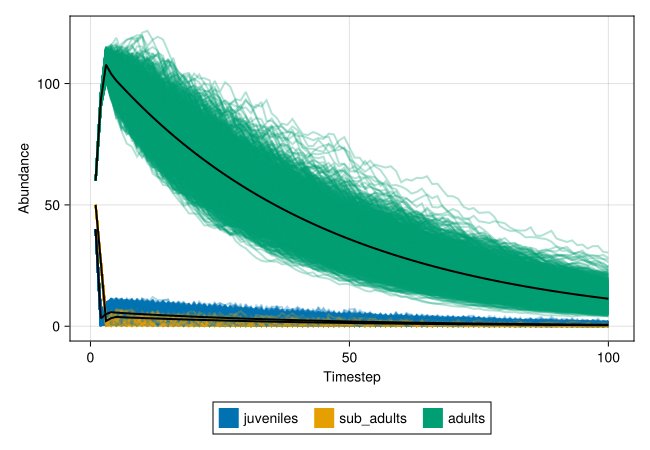

```julia
fig = Figure(size=(650, 450))
ax = Axis(fig[1,1], xlabel="Timestep", ylabel="Abundance")

idx = rand(1:100000, 2000)
colours = Makie.wong_colors()[1:3] # Use the same colour palette as AlgebraOfGraphics.jl

for i in idx
    series!(ax, stochastic_results[:, :, i], color=map(x -> (x, 0.3), colours))
end

# Add the original deterministic projections on top
series!(ax, projections_100t, solid_color=:black)

legend_entries = [
    PolyElement(; color=colours[1]),
    PolyElement(; color=colours[2]),
    PolyElement(; color=colours[3])
]
Legend(
    fig[2, 1],
    legend_entries,
    ["juveniles", "sub_adults", "adults"];
    tell_width=false,
    tell_height=false,
    orientation=:horizontal
)

fig
```